# **Fatal Police Shootings from 2015 to 2020**

**made by Ronald Lagos**

## Introduction

There has been political/social turnmoil this year, aside from a virus and outrageous presidential elections a controversial topic has been Black Lives Matter. While the name itself isn't something that should be debated people have made this a political issue too. In Fox news people such as *Tucker Carlson* say that "If we're going to survive as a country, we must defeat Black Lives Matter" treating the movement as a fascist group. Meanwhile, people on CNN such as anchor *Don Lemon* believe that "Black Lives Matters is about police brutality not black on black crime; black people face discrimination everyday." According to an article in *prnewswire* there is a about 63% of Democrats believe "Black Lives Matter" and 87% of Republicans believe that "All Lives Matter."

### So what does this leave us with?

This has left people confused, angry, anxious, afraid, and annoyed. Everyone has different opinions on every topic and **that's okay** but in times like these we can trust one thing and that is data. Lucky for us the Washington Post has gathered data of fatal police shootings from 2015 to 2020. Some may argue that Washington Post is very liberal. However, data is data. We are going to check out which race has gone through the most fatal shootings in the past 5 years. This data has the race of deceased, circumstances of the shooting, whether the person was armed, whether the victim was experiencing a mental health crisis, and others.

*We are not going to make any conclusions we are just interpreting the data that is given*

**Required Tools**

- requests
- pandas
- numpy
- bs4
- matplotlib.pyplot
- sklearn
- gmaps
- ipywidgets.embed
- tabulate
- folium
- geopy.geocoders

We highly recommend using this resource to learn how to import libraries in to your python code https://www.digitalocean.com/community/tutorials/how-to-import-modules-in-python-3

### Data Collection

- **requests:** Requests will allow you to send HTTP/1.1 requests using Python, we will use it to request data
- **pandas:** handle the vast majority of typical use cases in finance, statistics, social science, and many areas of engineering. We will use it to gather data.
- **numpy:** NumPy is a Python library used for working with arrays, it also has functions for working in domain of linear algebra, fourier transform, and matrices. We can use this to.
- **bs4:** This pulls out data out of HTML.
- **matplotlib.pyplot:** This helps matplotlib work like matlab; more resources about matlab can be found here, https://www.mathworks.com/help/stats/continuous-distributions.html?s_tid=CRUX_lftnav
- **sklearn:** Open source machine learning libraries in Python.
- **gmaps:** is a google plug in for embedding Google maps in Jupyter notebooks.
- **ipywidgets.embed:** Jupyter interactive widgets.
- **tabulate:** Helps print small tables without the hassle, transforms data into tables.
- **folium:** Helps visualize data in Python through leaflet maps
- **geopy.geocoders:** Helps Python developers locate coordinates of addresses and locations.

```python
import requests
import pandas as pd
import numpy as np
from bs4 import BeautifulSoup
import matplotlib.pyplot as plt
from sklearn import linear_model
import gmaps
import gmaps.datasets
from ipywidgets.embed import embed_minimal_html
from tabulate import tabulate
import folium
from geopy.geocoders import Nominatim
```

Below, the *get_csv* function will print out all of the data. We are going to get a data frame here and as you can see there are a lot of unnecessary columns. It is a really long list when all we really care about for this project is the race, age, and location of the person; once we continue to data processing we can clean the data.

```python
def get_csv():
    csv_df = pd.read_csv(r'./fatal-police-shootings-data.csv')
    print(tabulate(csv_df, tablefmt='psql', headers='keys'))
    return csv_df
```

Lets call the function and get the table with all of the data

```python
csv_data = get_csv()
```

```
+------+------+----------------------------------+------------+-------------------+----------------------------------+-------+----------+--------+--------------------------------+---------+---------------------------+----------------+-------------+---------------+
|      |   id | name                             | date       | manner_of_death   | armed                            |   age | gender   | race   | city                           | state   | signs_of_mental_illness   | threat_level   | flee        | body_camera   |
|------+------+----------------------------------+------------+-------------------+----------------------------------+-------+----------+--------+--------------------------------+---------+---------------------------+----------------+-------------+---------------|
|    0 |    3 | Tim Elliot                       | 2015-01-02 | shot              | gun                              |    53 | M        | A      | Shelton                        | WA      | True                      | attack         | Not fleeing | False         |
|    1 |    4 | Lewis Lee Lembke                 | 2015-01-02 | shot              | gun                              |    47 | M        | W      | Aloha                          | OR      | False                     | attack         | Not fleeing | False         |
|    2 |    5 | John Paul Quintero               | 2015-01-03 | shot and Tasered  | unarmed                          |    23 | M        | H      | Wichita                        | KS      | False                     | other          | Not fleeing | False         |
|    3 |    8 | Matthew Hoffman                  | 2015-01-04 | shot              | toy weapon                       |    32 | M        | W      | San Francisco                  | CA      | True                      | attack         | Not fleeing | False         |
|    4 |    9 | Michael Rodriguez                | 2015-01-04 | shot              | nail gun                         |    39 | M        | H      | Evans                          | CO      | False                     | attack         | Not fleeing | False         |
|    5 |   11 | Kenneth Joe Brown                | 2015-01-04 | shot              | gun                              |    18 | M        | W      | Guthrie                        | OK      | False                     | attack         | Not fleeing | False         |
|    6 |   13 | Kenneth Arnold Buck              | 2015-01-05 | shot              | gun                              |    22 | M        | H      | Chandler                       | AZ      | False                     | attack         | Car         | False         |
|    7 |   15 | Brock Nichols                    | 2015-01-06 | shot              | gun                              |    35 | M        | W      | Assaria                        | KS      | False                     | attack         | Not fleeing | False         |
|    8 |   16 | Autumn Steele                    | 2015-01-06 | shot              | unarmed                          |    34 | F        | W      | Burlington                     | IA      | False                     | other          | Not fleeing | True          |
|    9 |   17 | Leslie Sapp III                  | 2015-01-06 | shot              | toy weapon                       |    47 | M        | B      | Knoxville                      | PA      | False                     | attack         | Not fleeing | False         |
|   10 |   19 | Patrick Wetter                   | 2015-01-06 | shot and Tasered  | knife                            |    25 | M        | W      | Stockton                       | CA      | False                     | attack         | Not fleeing | False         |
|   11 |   21 | Ron Sneed                        | 2015-01-07 | shot              | gun                              |    31 | M        | B      | Freeport                       | TX      | False                     | attack         | Not fleeing | False         |
|   12 |   22 | Hashim Hanif Ibn Abdul-Rasheed   | 2015-01-07 | shot              | knife                            |    41 | M        | B      | Columbus                       | OH      | True                      | other          | Not fleeing | False         |
|   13 |   25 | Nicholas Ryan Brickman           | 2015-01-07 | shot              | gun                              |    30 | M        | W      | Des Moines                     | IA      | False                     | attack         | Car         | False         |
```

[output cut: 5325 more lines]

### Data Processing

Since we have many columns that we won't be using we will *tidy up* the data to it is easier to analyze. Since we will be altering the structure of a Dataframe this is considered *Data Wrangling*. Below is the code that shows us how to tidy it up.

```python
def get_new_csv():
    global csv_data
    new_df = csv_data[['race', 'age', 'state']]
    new_df = new_df.rename({'state': 'location'}, axis=1)
    # print csv data
    new_df.style.set_table_styles([{
        'selector': '',
        'props': [('border', '15px solid blue')]
    }])
    print(tabulate(new_df, tablefmt='psql', headers='keys'))
    new_df['race'] = new_df['race'].map(
        {
            'A': 'Asian',
            'B': 'Black',
            'O': 'Other',
            'W': 'White',
            'H': 'Hispanic'
        })

    # print replaced csv data
    print(tabulate(new_df, tablefmt='psql', headers='keys'))
    return new_df
```

We call the get_new_csv function

```python
dataframe = get_new_csv()
```

```
+------+--------+-------+------------+
|      | race   |   age | location   |
|------+--------+-------+------------|
|    0 | A      |    53 | WA         |
|    1 | W      |    47 | OR         |
|    2 | H      |    23 | KS         |
|    3 | W      |    32 | CA         |
|    4 | H      |    39 | CO         |
|    5 | W      |    18 | OK         |
|    6 | H      |    22 | AZ         |
|    7 | W      |    35 | KS         |
|    8 | W      |    34 | IA         |
|    9 | B      |    47 | PA         |
|   10 | W      |    25 | CA         |
|   11 | B      |    31 | TX         |
|   12 | B      |    41 | OH         |
|   13 | W      |    30 | IA         |
|   14 | B      |    37 | LA         |
|   15 | W      |    28 | MT         |
|   16 | W      |    42 | UT         |
|   17 | B      |    36 | AR         |
|   18 | W      |    49 | UT         |
|   19 | W      |    71 | AR         |
|   20 | H      |    33 | TX         |
|   21 | W      |    39 | IL         |
|   22 | H      |    23 | CA         |
|   23 | H      |    29 | NV         |
|   24 | W      |    34 | NM         |
|   25 | W      |    43 | TX         |
|   26 | B      |    24 | MN         |
|   27 | W      |    29 | MO         |
|   28 | B      |    34 | VA         |
|   29 | W      |    75 | NJ         |
|   30 | W      |    68 | TX         |
|   31 | W      |    34 | UT         |
|   32 | B      |    27 | IN         |
|   33 | B      |    39 | CO         |
|   34 | W      |    24 | MN         |
|   35 | H      |    36 | CA         |
|   36 | W      |    33 | LA         |
```

[output cut: 10629 more lines]

```
| 5324 | Black    |    38 | TX         |
| 5325 | Hispanic |    25 | WA         |
| 5326 | nan      |    49 | TN         |
| 5327 | White    |    64 | AR         |
| 5328 | nan      |   nan | WI         |
| 5329 | White    |    32 | AL         |
| 5330 | nan      |    69 | FL         |
| 5331 | White    |    29 | TN         |
| 5332 | nan      |   nan | WA         |
| 5333 | nan      |   nan | FL         |
| 5334 | nan      |    44 | TN         |
| 5335 | nan      |    43 | TN         |
| 5336 | Hispanic |    38 | TX         |
| 5337 | White    |    61 | FL         |
+------+----------+-------+------------+
```

### Exploratory Analysis and Data Visualization

This is the Exploratory Analysis and Visualization stage of the data life cycle where we attempt to plot our data in order to observe potential trends or correlations. Keeping in mind that correlation does not mean causation.

```python
# show bar chart with age vs race
def draw_age_vs_race_graph(df):
    data = df.groupby('age').count()
    data.plot(y='race', kind='bar', position=0, figsize=(18, 5))
    plt.show()
```

This is a bar graph that will tell us what age races (any) were in the most fatal shots by police. As we can see the age that people got fatally shot by police the most is age of 25 years old

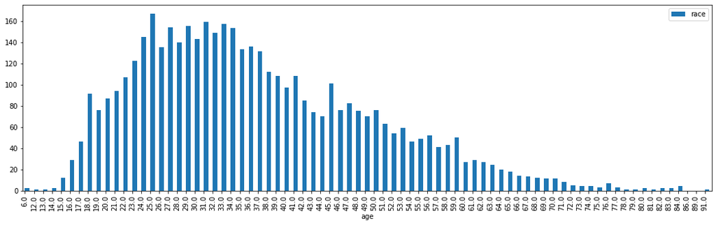

```python
draw_age_vs_race_graph(dataframe)
```

This function is the location vs race

```python
# show bar chart with location vs race
def draw_location_vs_race_graph(df):
    data = df.groupby('location').count()
    data.plot(y='race', kind='bar', position=0, figsize=(18, 5))
    plt.show()
```

Here we can see that the location where most people die of fatal police shootings is California, since 2015

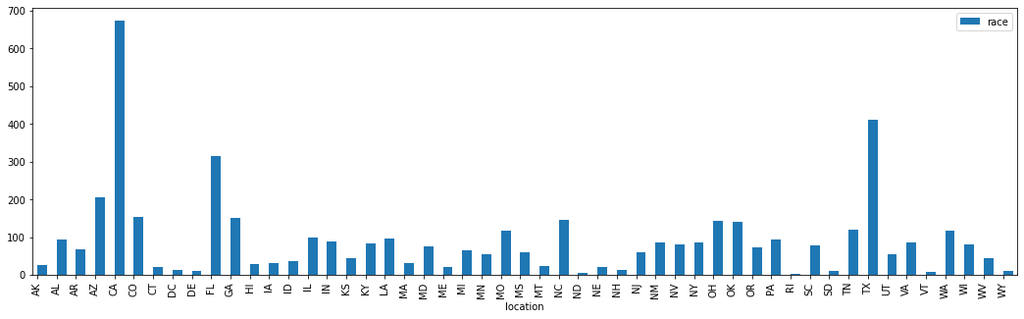

```python
draw_location_vs_race_graph(dataframe)
```

Next we will look at a function that outputs a pie chart. We group it by race and simply call plot.pie

```python
def draw_pie_by_race(df):
    data = df.groupby('race').count()
    data.plot.pie(figsize=(5, 5), startangle=90, subplots=True)
    plt.show()
```

Below I made two pie charts one based on location and another based on age. Ther isn't much difference in those but we can see that the pie charts indicate the race that is killed the most in the US since 2015 are white people

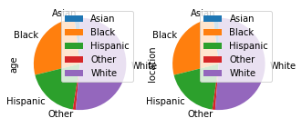

```python
draw_pie_by_race(dataframe)
```

The function *get_state_location* will help us get the states and make a table out of it

```python
def get_state_location():
    df_list = []
    req = requests.get("https://developers.google.com/public-data/docs/canonical/states_csv")
    soup = BeautifulSoup(req.content, 'html.parser')
    table_list = str(soup.find('table'))
    df_list.append(pd.read_html(table_list, flavor='html5lib', header=0)[0])
    df = pd.concat(df_list)
    return df
```

```python
# draw heat map
def draw_heat_map(df):
    data = df.groupby('location').count()
    data['state'] = data.index
    data = data.drop(columns=['age'])
    data = data.reset_index()
    locations = get_state_location()
    heatmap = folium.Map(
        location=[47.751074, -120.740139],
        zoom_start=3
    )
    tooltip = 'Click Here!'
    info_box_template = """
    <dl>
    <dt>Race</dt><dd>{race}</dd>
    </dl>
    """
    for x in data.itertuples():
        location_row = locations.loc[locations['state'] == x[1]]
        folium.Marker([location_row.iloc[0]['latitude'], location_row.iloc[0]['longitude']],
                      popup=info_box_template.format(race=x[2]), tooltip=tooltip).add_to(heatmap)

    heatmap.save('index.html')
    ca_data = csv_data[csv_data.state.eq('CA')]
    new_df = ca_data[['race', 'age', 'state', 'city']]
    new_df = new_df.rename({'state': 'location'}, axis=1)
    # print csv data
    new_df.style.set_table_styles([{
        'selector': '',
        'props': [('border', '15px solid blue')]
    }])
    new_df['race'] = new_df['race'].map(
        {
            'A': 'Asian',
            'B': 'Black',
            'O': 'Other',
            'W': 'White',
            'H': 'Hispanic'
        })

    ca_data = new_df

    data = ca_data.groupby('city').count()
    data = data.reset_index()
    data = data.drop(columns=['age', 'location'])

    print(tabulate(data, tablefmt='psql', headers='keys'))

    max_data = data.iloc[data['race'].idxmax()]
    print('***************************')
    print('The most race in California:')
    print(max_data)
    max_data = ca_data[ca_data.city.eq(max_data[0])]
    max_data = max_data.reset_index()
    max_data = max_data.drop(columns=['age', 'city', 'location'])
    max_data = max_data.groupby('race').count()
    max_data = max_data.rename({'index': 'count'}, axis=1)
    print('***************')
    print(max_data)
    # geo_locator = Nominatim(user_agent='heatmap')

    # for x in data.itertuples():
    #     loc = geo_locator.geocode(x[1] + ' CA United State')
    #     print((loc.latitude, loc.longitude))

    # info_box_template = """
    # <dl>
    # <dt>Race</dt><dd>{race}</dd>
    # </dl>
    # """
    # info = [info_box_template.format(race=x[2]) for x in data.itertuples()]
    # plant_locations = []
    # for x in data.itertuples():
    #     location_row = locations.loc[locations['state'] == x[1]]
    #     plant_locations.append((location_row.iloc[0]['latitude'], location_row.iloc[0]['longitude']))
    #
    # gmaps.configure(api_key="AIzaSyDud4sLgiVgMmaxFRkiTpJ9cBoRZsr4atI")
    # marker_layer = gmaps.marker_layer(plant_locations, info_box_content=info)
    # fig = gmaps.figure()
    # fig.add_layer(marker_layer)
    #
    # embed_minimal_html('export.html', views=[fig])


draw_heat_map(dataframe)
```

```
+-----+---------------------------+--------+
|     | city                      |   race |
|-----+---------------------------+--------|
|   0 | Adelanto                  |      1 |
|   1 | Aguanga                   |      0 |
|   2 | Alhambra                  |      1 |
|   3 | Alpine                    |      2 |
|   4 | Anaheim                   |     10 |
|   5 | Anderson                  |      2 |
|   6 | Antelope                  |      1 |
|   7 | Antioch                   |      4 |
|   8 | Apple Valley              |      1 |
|   9 | Arcata                    |      1 |
|  10 | Artesia                   |      0 |
|  11 | Ashland                   |      1 |
|  12 | Atascadero                |      1 |
|  13 | Atwater                   |      3 |
|  14 | Auburn                    |      1 |
|  15 | Avenal                    |      1 |
|  16 | Azusa                     |      4 |
|  17 | Bakersfield               |     22 |
|  18 | Baldwin Hills             |      1 |
|  19 | Banning                   |      1 |
|  20 | Barona Indian Reservation |      1 |
|  21 | Barstow                   |      4 |
|  22 | Bassett                   |      1 |
|  23 | Beaumont                  |      1 |
|  24 | Bell                      |      1 |
|  25 | Bell Gardens              |      1 |
|  26 | Bellflower                |      1 |
|  27 | Big Sur                   |      1 |
|  28 | Boulder Creek             |      1 |
|  29 | Boyle Heights             |      1 |
|  30 | Brawley                   |      0 |
|  31 | Brea                      |      0 |
|  32 | Burbank                   |      2 |
|  33 | Butte County              |      0 |
|  34 | Byron                     |      0 |
|  35 | Cabazon                   |      1 |
|  36 | Calabasas                 |      1 |
```

[output cut: 285 more lines]

```
| 322 | Yreka                     |      0 |
| 323 | Yuba City                 |      2 |
| 324 | Yucca Valley              |      2 |
+-----+---------------------------+--------+
The most race in California:
city    Los Angeles
race             76
Name: 161, dtype: object
***************
          count
race
Asian         2
Black        16
Hispanic     43
White        15
```

### **Observations**

During this phase of the Data Lifecycle, we attempt to perform various modeling techniques such as linear regression and logistic regression. We will perforn a linear regression race vs age. X-axis being age and Y axis is race (not specified)

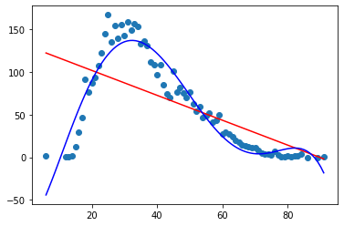

```python
# show linear graph
def draw_linear_graph(df):
    data = df.groupby('age').count()
    data = data.drop(columns=['location'])
    data['tmp'] = data.index

    # get prediction value
    x = data.iloc[:, 1].values.reshape(-1, 1)
    y = data.iloc[:, 0].values.reshape(-1, 1)
    linear_regressor = linear_model.LinearRegression()
    linear_regressor.fit(x, y)
    y_pred = linear_regressor.predict(x)

    # draw plot
    plt.scatter(x, y)

    # draw linear regression
    plt.plot(x, y_pred, color='red')

    # draw polynomial line
    deg = 5
    poly_data = np.poly1d(np.polyfit(data.index, data['race'], deg))
    polyline = np.linspace(data.index.min(), data.index.max(), 100)
    plt.plot(polyline, poly_data(polyline), color='blue')
    plt.show()


draw_linear_graph(dataframe)
```

**With that said, can we really trust media?**